# Final_Nirf_Ranking_Dataset_Analysis_Project_by_SHUBHAM KUMAR

#### Conclusion : This Shows that how different factors are varying over the years.

#### Query-19 : Distribution of colleges across cities in India

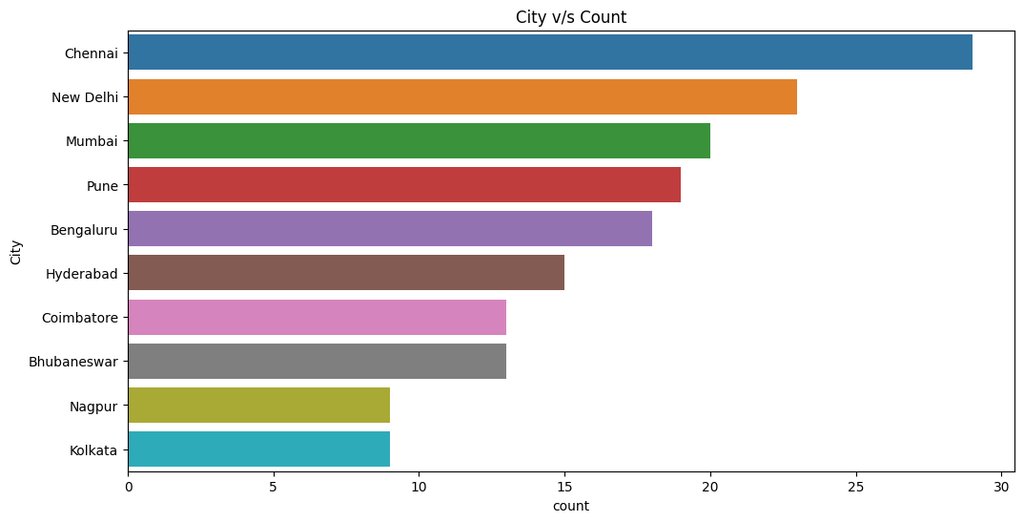

```python
data['City'].value_counts()
plt.figure(figsize=(12,6))
sns.countplot(y='City',order = data['City'].value_counts().index[0:10],data=data)
plt.title('City v/s Count')
```

#### Conclusion :

1.Chennai is the city with most colleges. 2.There are more colleges in metropolitan cites compared to other cities.

#### Query-20 : Top Colleges on the basis of Research and Professional Practice (RP)

```
<BarContainer object of 10 artists>
```

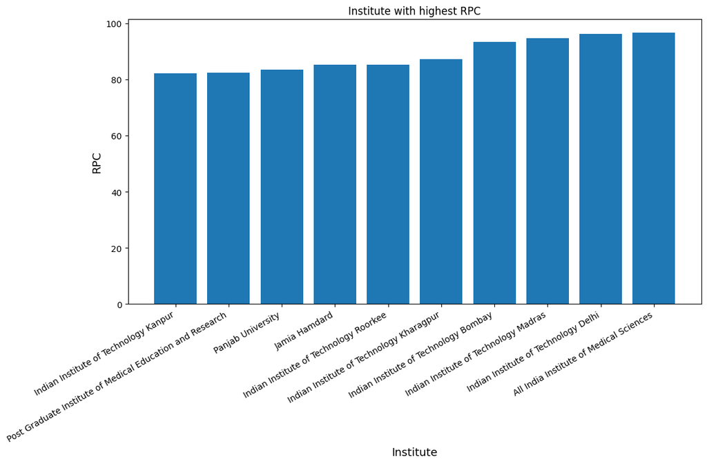

```python
states = data.sort_values(by='RPC').tail(10)
plt.rcParams['figure.figsize']=(12,6)
plt.title('Institute with highest RPC')
plt.xlabel('Institute', fontsize=13)
plt.ylabel('RPC', fontsize=13)
plt.xticks(rotation=30,ha='right')
plt.bar(states.Name,states.RPC)
```

## Final Outcomes of our Analysis :

From the analysis, it is observed that NIRF ranking has attracted more participation of institution of higher education from across india in all categories and subject domains.The number of particiapants has increased every year.It may also be noted that highest number of institutions are located in southern region of India.Major number of institute are in Tamil Nadu.And among these institutes most are in chennai.